# Assignment 1

Mason Sharum

2025-09-24

I completed 15/15 questions in this assignment.

# Question 1

Below is the table of grading weights for the course.

| Group | Amount | Total Weight |
| --- | --- | --- |
| Assignments | 4 | 15% |
| Laboratories | 16 | 10% |
| Projects | 2 | 10% |
| In Class Quizzes | TBD | 10% |
| Chapter Quizzes | TBD | 5% |
| Mid-Term Exam | 1 | 20% |
| Final Exam | 1 | 30% |

The grading scale is as follows: A (100-90) B(89-80) C(79-60) D(59-50) F(<50), and there will be no curves.

# Question 2

```r
ddt <- read.csv("DDT.csv")
head(ddt)
```

```
##   RIVER MILE  SPECIES LENGTH WEIGHT DDT
## 1   FCM    5 CCATFISH   42.5    732  10
## 2   FCM    5 CCATFISH   44.0    795  16
## 3   FCM    5 CCATFISH   41.5    547  23
## 4   FCM    5 CCATFISH   39.0    465  21
## 5   FCM    5 CCATFISH   50.5   1252  50
## 6   FCM    5 CCATFISH   52.0   1255 150
```

```r
ddt$MILE = factor(ddt$MILE)
```

## (a)

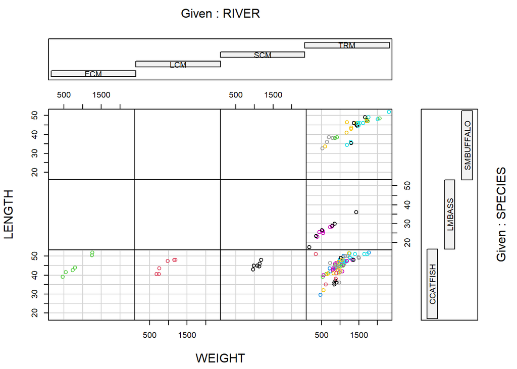

```r
with(ddt, coplot(LENGTH ~ WEIGHT | RIVER * SPECIES, ddt, col = MILE))
```

## (b)

The length and weight of catfish found in the FCM, LCM, and SCM rivers increase together in a positive correlation.

## (c)

Line A is a function call that creates a factor object of the MILE variable, meaning it makes a vector of the measurements from MILE after sorting them into categories.

## (d)

Line B is a function call that returns the number of unique values in the previously made vector. For instance if the vector was [1, 1, 2, 3, 3], it would return 3 since there are three unique numbers.

## (e)

The top six plots are empty because there are no fish that are either LMBASS or SMBUFFALO that were caught in the FCM, LCM, or SCM rivers.

## (f)

```r
cat = subset(ddt, RIVER == "FCM" & SPECIES == "CCATFISH",)
mean(cat$DDT)
```

```
## [1] 45
```

# Question 3

## (a)

Length of the maximum span (feet) is a quantitative variable.

## (b)

Number of vehicle lanes is a quantitative variable.

## (c)

TOll bridge (yes or no) is a qualitative variable.

## (d)

Average daily traffic is a quantitative variable.

## (e)

Condition of deck (good, fair, poor) is a qualitative variable.

## (f)

Bypass or detour length (miles) is a quantitative variable.

## (g)

Route type (interstate, U.S., state, county, or city) is a qualitative variable.

# Question 4

## (a)

The four random sampling designs are as follows: simple random sampling, stratified random sampling, cluster sampling, and systematic sampling.

## (b)

Simple random sampling happens when n experimental units are selected from the population in such a way that every different sample of size n has an equal chance of selection.

Stratified random sampling happens when the population is separated into different strata based off of certain characteristics of the experimental units. These strata are then randomly sampled from.

Cluster sampling happens when a group(or cluster) is selected from within the population and then data is taken about every unit in the cluster.

Systematic sampling happens when every kth experimental unit is selected from a list of all experimental units.

# Question 5

```r
mtbe <- read.csv("MTBE.csv")
head(mtbe)
```

```
##     pH SpConduct DissOxy RoadsPct IndPct UrbanPct DevPct WellClass Aquifier
## 1 7.87     290.0    0.58     1.34      0    17.77  17.77   Private  Bedrock
## 2 8.63     225.9    0.84     0.72      0    10.43  10.43   Private  Bedrock
## 3 7.11     157.4    8.37     1.92      0    29.62  50.01   Private  Bedrock
## 4 7.98     723.6    0.41     2.76      0    41.65  41.65   Private  Bedrock
## 5 7.88     148.7    1.44     3.51      0    51.21  51.21   Private  Bedrock
## 6 8.36     198.2    0.18     1.48      0    22.49  29.19   Private  Bedrock
##     Depth SafeYld Distance MTBE.Detect MTBE.Level HouseDen PopDen
## 1  60.960      NA  2386.29 Below Limit        0.2   131.16  43.19
## 2  36.576      NA  3667.69 Below Limit        0.2    47.69  24.52
## 3 152.400      NA  2324.15 Below Limit        0.2    85.16  33.32
## 4      NA      NA   788.88 Below Limit        0.2   134.77  46.61
## 5  91.440      NA  1337.88 Below Limit        0.2   198.54  78.58
## 6 115.824      NA  2396.74 Below Limit        0.2   206.73  59.47
```

```r
ind = sample(1:223, 5, replace = FALSE)
mtbe[ind,]
```

```
##       pH SpConduct DissOxy RoadsPct IndPct UrbanPct DevPct WellClass  Aquifier
## 58  7.24     693.0    0.39     1.93   0.00    27.48  27.48   Private   Bedrock
## 48  8.10     165.0    0.42     3.08   0.00    63.59  66.62   Private   Bedrock
## 216 6.60     411.5    7.99     1.88   0.84    33.55  33.55    Public Unconsoli
## 154 7.97     304.8    0.48     3.14   8.87    26.68  26.68    Public   Bedrock
## 3   7.11     157.4    8.37     1.92   0.00    29.62  50.01   Private   Bedrock
##       Depth  SafeYld Distance MTBE.Detect MTBE.Level HouseDen PopDen
## 58  115.824       NA  2167.92      Detect       0.24   169.69  56.16
## 48       NA       NA  2277.12 Below Limit       0.20   204.43  63.70
## 216  15.240       NA   596.88 Below Limit       0.20    92.24  33.89
## 154 182.880 94.62528   391.18      Detect       6.43   141.84  68.93
## 3   152.400       NA  2324.15 Below Limit       0.20    85.16  33.32
```

## (a)

### (i)

```r
mtbeo = na.omit(mtbe)
```

### (ii)

```r
depth = mtbeo[mtbeo$Aquifier == "Bedrock",]$Depth
sd(depth)
```

```
## [1] 56.45357
```

# Question 6

```r
eq <- read.csv("EARTHQUAKE.csv")
head(eq)
```

```
##   YEAR MONTH DAY HOUR MINUTE MAGNITUDE
## 1 1994     1  17   12     30       6.7
## 2 1994     1  17   12     31       5.5
## 3 1994     1  17   12     32       3.3
## 4 1994     1  17   12     34       4.2
## 5 1994     1  17   12     36       3.8
## 6 1994     1  17   12     37       3.7
```

```r
ind = sample(1:2929, 30, replace = FALSE)
eq[ind,]
```

```
##      YEAR MONTH DAY HOUR MINUTE MAGNITUDE
## 28   1994     1  17   13     25       3.5
## 2271 1994     1  29   14      3       3.4
## 1280 1994     1  23    4     15       2.3
## 1147 1994     1  22   13     49       2.9
## 383  1994     1  19    4     17       2.2
## 1162 1994     1  22   14     59       2.3
## 648  1994     1  20    8     25       1.9
## 2148 1994     1  28   17     30       1.5
## 1927 1994     1  27    1     55       1.8
## 557  1994     1  19   23     18       2.6
## 1616 1994     1  25    3     43       2.2
## 42   1994     1  17   14      3       3.7
## 1609 1994     1  25    3      6       1.4
## 2443 1994     2   1   14     31       1.5
```

[output cut: 16 more lines]

## (a)

### (i)

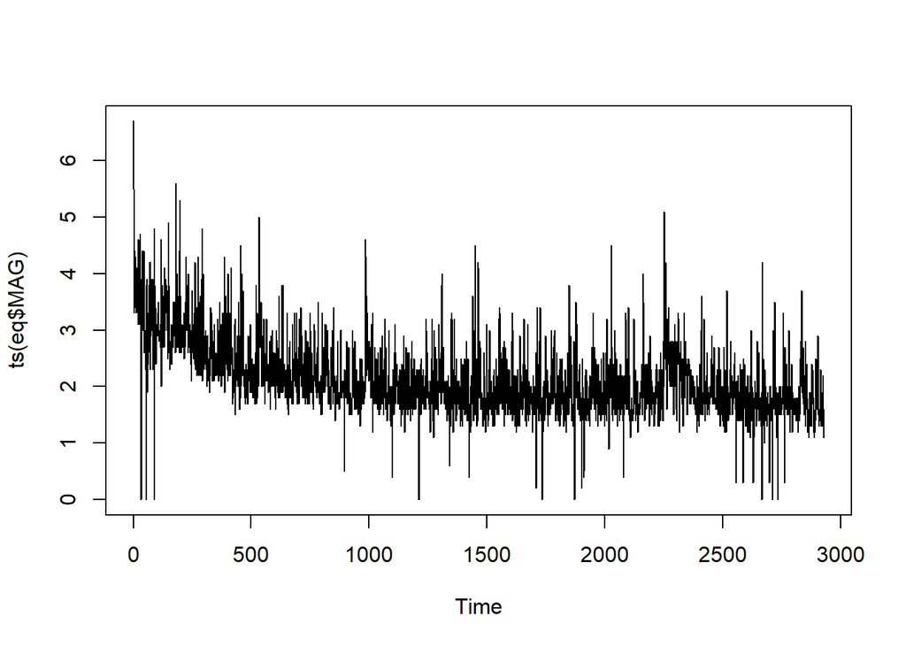

```r
plot(ts(eq$MAG))
```

```r
median(eq$MAGNITUDE)
```

```
## [1] 2
```

# Question 7

## (a)

The data was collected with a stratified sample.

## (b)

The population is all of the fish in the Tennessee River.

## (c)

The qualitative variables are location and species. Location was divided into river and mile.

# Question 8

## (a)

A bar graph is used to describe the data.

## (b)

The variable measured for each of the 106 robot designs was type of robotic limbs.

## (c)

The current most used design of robot is legs only.

## (d)

```r
limb_freq = c(15, 8, 63, 20)
limb_labels = c("None", "Both", "Legs", "Wheels")
rel_freq = as.data.frame(matrix(data = limb_freq/sum(limb_freq), nrow = 4, ncol = 1), row.names = limb_labels)
rel_freq
```

```
##               V1
## None   0.1415094
## Both   0.0754717
## Legs   0.5943396
## Wheels 0.1886792
```

## (e)

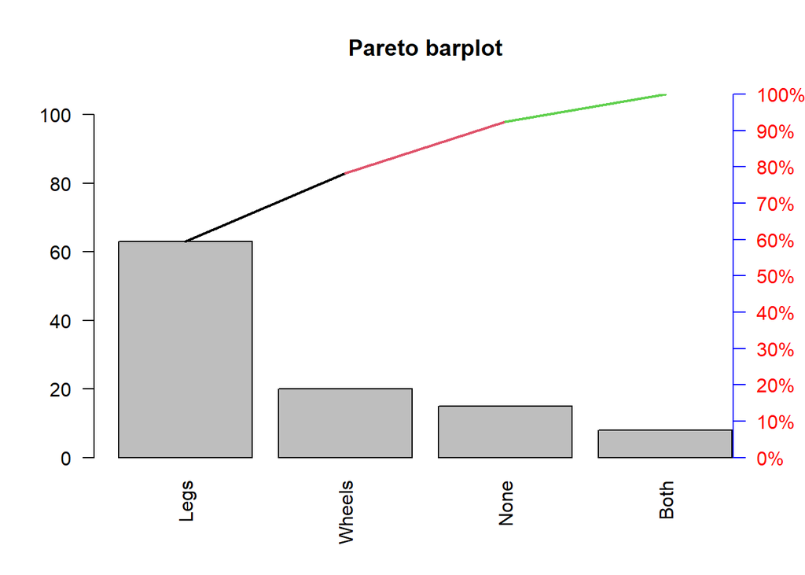

```r
source("pareto.r")
l = rep(limb_labels, limb_freq)
pareto(l)
```

# Question 9

## (a)

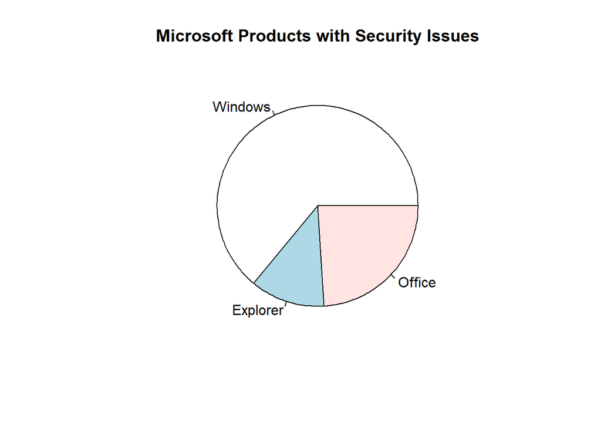

```r
nums = c(32, 6, 12)
labs = c("Windows", "Explorer", "Office")
pie(nums, labels = labs, main = "Microsoft Products with Security Issues")
```

## (b)

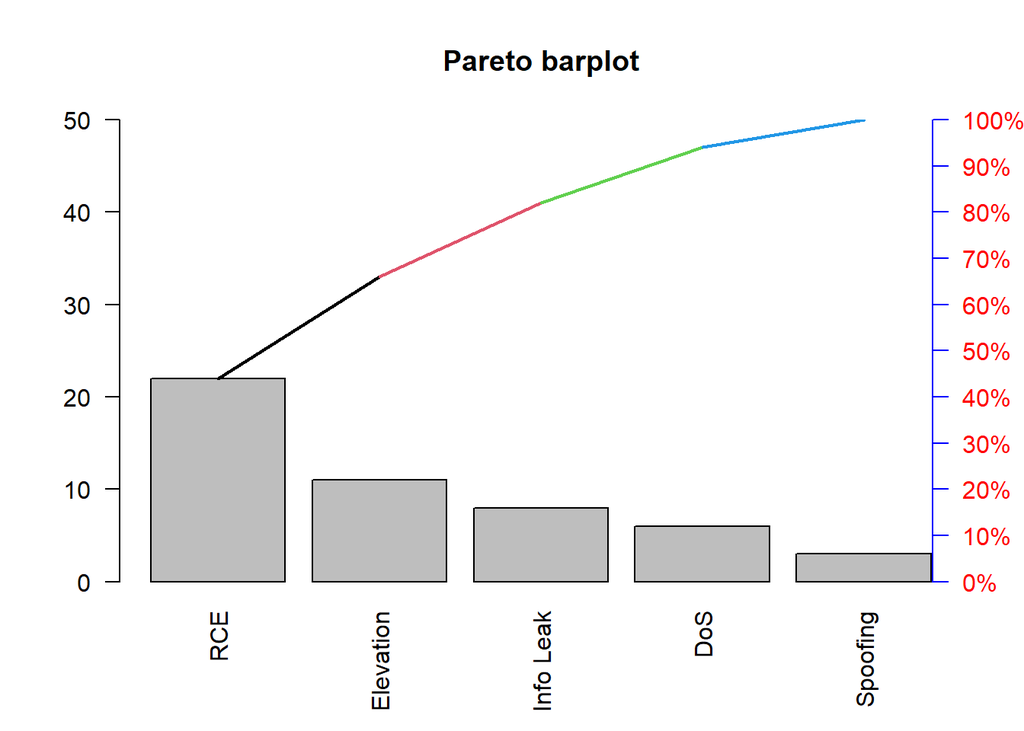

```r
MSFreq = c(6, 8, 22, 3, 11)
MSLabel = c("DoS", "Info Leak", "RCE", "Spoofing", "Elevation")
MS = rep(MSLabel, MSFreq)
pareto(MS)
```

Based on this diagram, I would say they should focus on fixing the Remote Code Execution problem, as that seems to be the most commonly used exploit.

# Question 10

```r
swd = read.csv("SWDEFECTS.csv")
head(swd)
```

```
##   Mloc Mvg Mevg Mivg   Hn  Hvol Hpgmlen Hdiff Hintell Heffort   Hb Htime Hloc
## 1  1.1 1.4  1.4  1.4  1.3   1.3    1.30  1.30    1.30       1 1.30     1    2
## 2  1.0 1.0  1.0  1.0  1.0   1.0    1.00  1.00    1.00       1 1.00     1    1
## 3 24.0 5.0  1.0  3.0 63.0 309.1    0.11  9.50   32.54    2937 0.10   163    1
## 4 20.0 4.0  4.0  2.0 47.0 215.5    0.06 16.00   13.47    3448 0.07   192    0
## 5 24.0 6.0  6.0  2.0 72.0 346.1    0.06 17.33   19.97    6000 0.12   333    0
## 6 24.0 6.0  6.0  2.0 72.0 346.1    0.06 17.33   19.97    6000 0.12   333    0
##   Hcomm Hblank loc.comm uniOp uniOpnd totOp totOpnd brnchcnt defect
## 1     2      2        2   1.2     1.2   1.2     1.2      1.4  FALSE
## 2     1      1        1   1.0     1.0   1.0     1.0      1.0   TRUE
## 3     0      6        0  15.0    15.0  44.0    19.0      9.0  FALSE
## 4     0      3        0  16.0     8.0  31.0    16.0      7.0  FALSE
## 5     0      3        0  16.0    12.0  46.0    26.0     11.0  FALSE
## 6     0      3        0  16.0    12.0  46.0    26.0     11.0  FALSE
##   predict.vg.10 predict.evg.14.5 predict.ivg.9.2 predict.loc.50
## 1            no               no              no             no
## 2            no               no              no             no
## 3            no               no              no             no
## 4            no               no              no             no
## 5            no               no              no             no
## 6            no               no              no             no
```

```r
library(plotrix)
tab = table(swd$defect)
rtab = tab/sum(tab)
round(rtab, 2)
```

```
##
## FALSE  TRUE
##   0.9   0.1
```

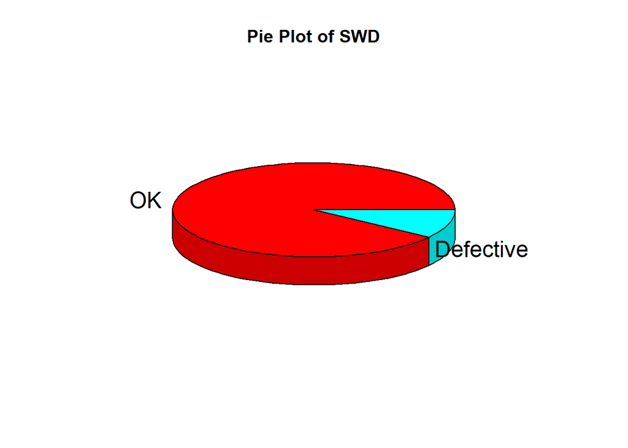

```r
pie3D(rtab, labels = list("OK", "Defective"), main = "Pie Plot of SWD")
```

# Question 11

## (a)

| Class | Class Interval | Data Tabulation | Frequency | Relative Frequency |
| --- | --- | --- | --- | --- |
| 1 | [8.0000,8.2900] | 8.05 | 1 | 0.0333 |
| 2 | (8.2900,8.5800] | - | 0 | 0.0000 |
| 3 | (8.5800,8.8700] | 8.72,8.72,8.80 | 3 | 0.1000 |
| 4 | (8.8700,9.1600] | - | 0 | 0.0000 |
| 5 | (9.1600,9.4500] | - | 0 | 0.0000 |
| 6 | (9.4500,9.7400] | 9.55,9.70,9.73 | 3 | 0.1000 |
| 7 | (9.7400,10.0200] | 9.80,9.80,9.84,9.84,9.87,9.87,9.95,9.97,9.98,9.98,10.00,10.01,10.02 | 13 | 0.4333 |
| 8 | (10.0200,10.3100] | 10.03,10.05,10.05,10.12,10.15,10.15,10.26,10.26,10.29 | 9 | 0.3000 |
| 9 | (10.3100,10.6000] | 10.55 | 1 | 0.0333 |
| Total | - | - | 30 | 1 |

```r
volt <- read.csv("VOLTAGE.csv")
head(volt)
```

```
##   VOLTAGE LOCATION
## 1    9.98      OLD
## 2   10.26      OLD
## 3   10.05      OLD
## 4   10.29      OLD
## 5   10.03      OLD
## 6    8.05      OLD
```

```r
old = volt[volt$LOCATION == "OLD",]
new = volt[volt$LOCATION == "NEW",]
vto = old$VOLTAGE
vto
```

```
##  [1]  9.98 10.26 10.05 10.29 10.03  8.05 10.55 10.26  9.97  9.87 10.12 10.05
## [13]  9.80 10.15 10.00  9.87  9.55  9.95  9.70  8.72  9.84 10.15 10.02  9.80
## [25]  9.73 10.01  9.98  8.72  8.80  9.84
```

```r
max(vto)
```

```
## [1] 10.55
```

```r
min(vto)
```

```
## [1] 8.05
```

```r
lept = min(vto) - 0.05
rept = max(vto) + 0.05
rnge = rept - lept
inc = rnge/9
inc
```

```
## [1] 0.2888889
```

```r
cl = seq(lept, rept,by = inc)
cl
```

```
##  [1]  8.000000  8.288889  8.577778  8.866667  9.155556  9.444444  9.733333
##  [8] 10.022222 10.311111 10.600000
```

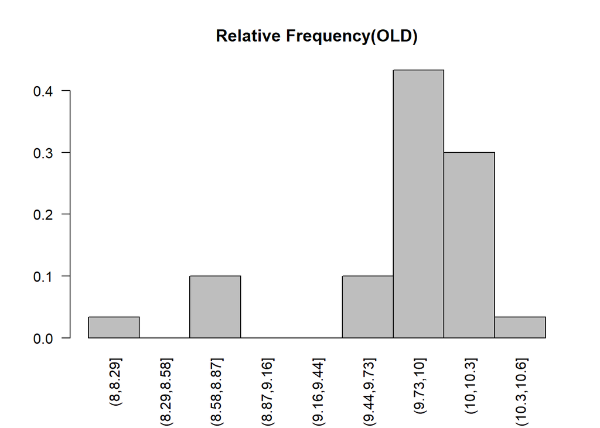

```r
cuts = cut(vto,breaks = cl)
old.tab = table(cuts)
barplot(old.tab / sum(old.tab), space = 0, main = "Relative Frequency(OLD)", las = 2)
```

## (b)

```r
volt <- read.csv("VOLTAGE.csv")
head(volt)
```

```
##   VOLTAGE LOCATION
## 1    9.98      OLD
## 2   10.26      OLD
## 3   10.05      OLD
## 4   10.29      OLD
## 5   10.03      OLD
## 6    8.05      OLD
```

```r
old = volt[volt$LOCATION == "OLD",]
new = volt[volt$LOCATION == "NEW",]
stem(x = old$VOLTAGE)
```

```
##
##   The decimal point is at the |
##
##    8 | 1
##    8 | 778
##    9 |
##    9 | 677888899
##   10 | 0000000011122333
##   10 | 6
```

Both graphs are equally informative about where most of the voltage readings lie. The stem and leaf display gives you exact numbers for how many are in each section though so that is a bit more descriptive but both are able to tell you which area has the most data points.

## (c)

```r
vtn = new$VOLTAGE
vtn
```

```
##  [1]  9.19  9.63 10.10  9.70 10.09  9.60 10.05 10.12  9.49  9.37 10.01  8.82
## [13]  9.43 10.03  9.85  9.27  8.83  9.39  9.48  9.64  8.82  8.65  8.51  9.14
## [25]  9.75  8.78  9.35  9.54  9.36  8.68
```

```r
max(vtn)
```

```
## [1] 10.12
```

```r
min(vtn)
```

```
## [1] 8.51
```

```r
lept = min(vtn) - 0.05
rept = max(vtn) + 0.05
rnge = rept - lept
inc = rnge/9
inc
```

```
## [1] 0.19
```

```r
cl = seq(lept, rept,by = inc)
cl
```

```
##  [1]  8.46  8.65  8.84  9.03  9.22  9.41  9.60  9.79  9.98 10.17
```

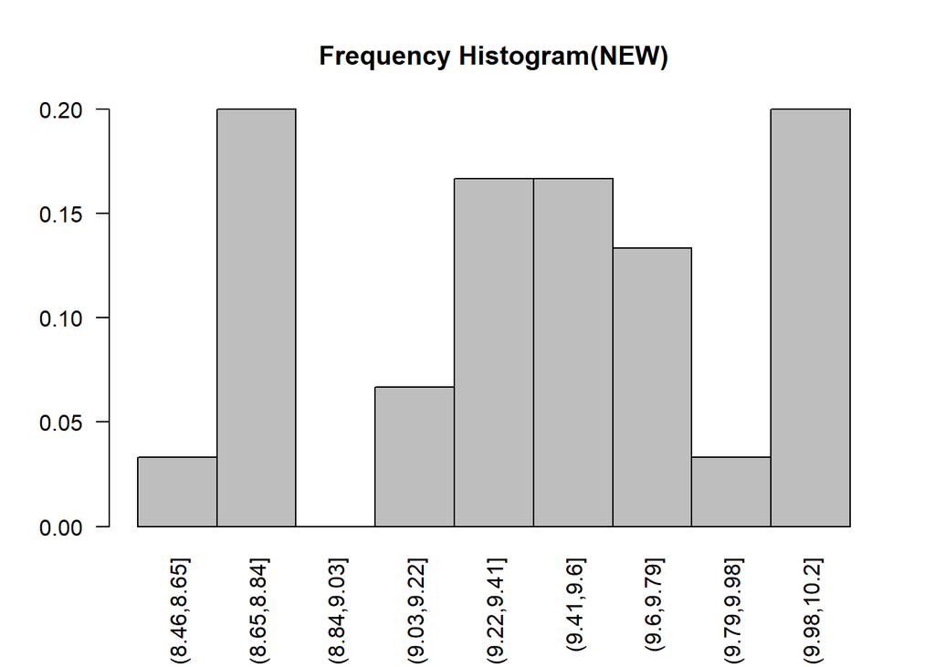

```r
cuts = cut(vtn,breaks = cl)
new.tab = table(cuts)
barplot(new.tab/sum(new.tab), space = 0, main = "Frequency Histogram(NEW)", las = 2)
```

## (d)

The new location has a lot more voltages that fall below the cutoff point of 9.2, while the old location has a lot less. This shows that the new location is not yet as good as the previous location and that they should probably not yet move over production.

## (e)

### OLD

```r
source("getmode.R")
mean(old$VOLTAGE)
```

```
## [1] 9.803667
```

```r
median(old$VOLTAGE)
```

```
## [1] 9.975
```

```r
getmode(old$VOLTAGE)
```

```
## [1] 9.98
```

The average reading is about 9.8 and the middle value is 9.975, while the most common value is 9.98. I would say that the mean is the best indicator of central tendency in this case, because the distribution is close to normal so the mean will be centralized.

### NEW

```r
mean(new$VOLTAGE)
```

```
## [1] 9.422333
```

```r
median(new$VOLTAGE)
```

```
## [1] 9.455
```

```r
getmode(new$VOLTAGE)
```

```
## [1] 8.82
```

The average reading is about 9.4 and the middle value is 9.455, while the most common value is 8.82. I would say that the mean is the best indicator of central tendency in this case, because the distribution is close to normal so the mean will be centralized.

## (f)

```r
(10.5 - mean(old$VOLTAGE))/sd(old$VOLTAGE)
```

```
## [1] 1.287324
```

## (g)

```r
(10.5 - mean(new$VOLTAGE))/sd(new$VOLTAGE)
```

```
## [1] 2.25041
```

## (h)

The reading of 10.5 is more likely to occur at the old location since it has a lower z-score at the old location meaning it is closer to the mean and therefore more likely to occur.

## (i)

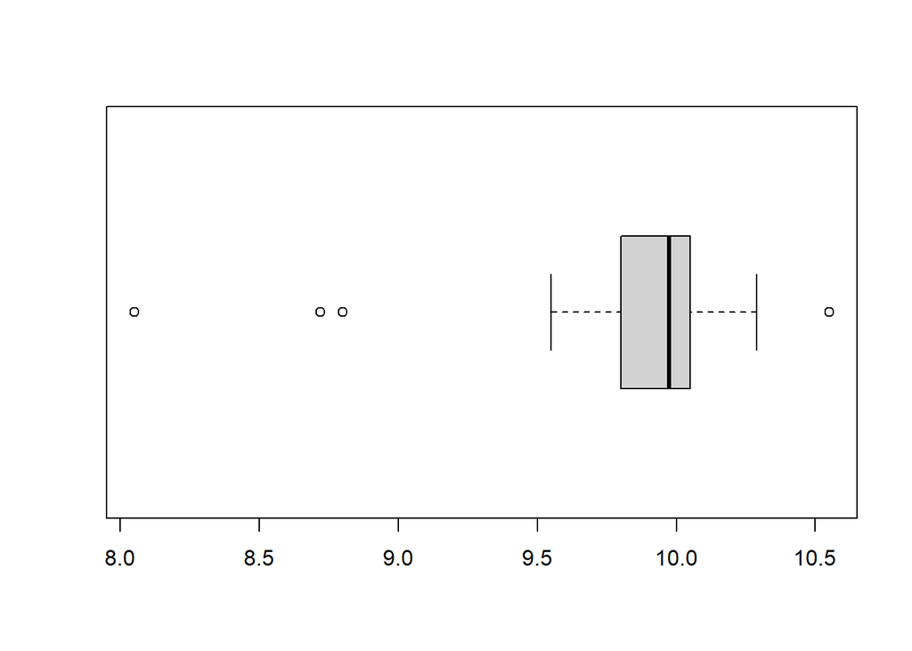

```r
boxplot(old$VOLTAGE, horizontal = T)
```

There appear to be outliers in the old location.

## (j)

```r
old[abs((old$VOLTAGE-mean(old$VOLTAGE))/sd(old$VOLTAGE)) > 3,]
```

```
##   VOLTAGE LOCATION
## 6    8.05      OLD
```

## (k)

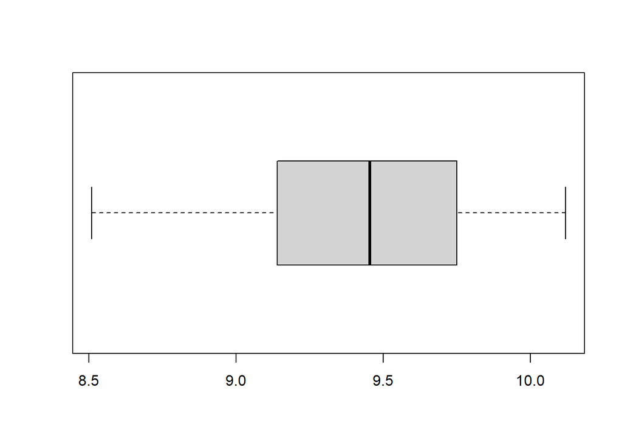

```r
boxplot(new$VOLTAGE, horizontal = T)
```

There does not seem to be any outliers based off of this boxplot.

## (l)

```r
new[abs((new$VOLTAGE-mean(new$VOLTAGE))/sd(new$VOLTAGE)) > 3,]
```

```
## [1] VOLTAGE  LOCATION
## <0 rows> (or 0-length row.names)
```

## (m)

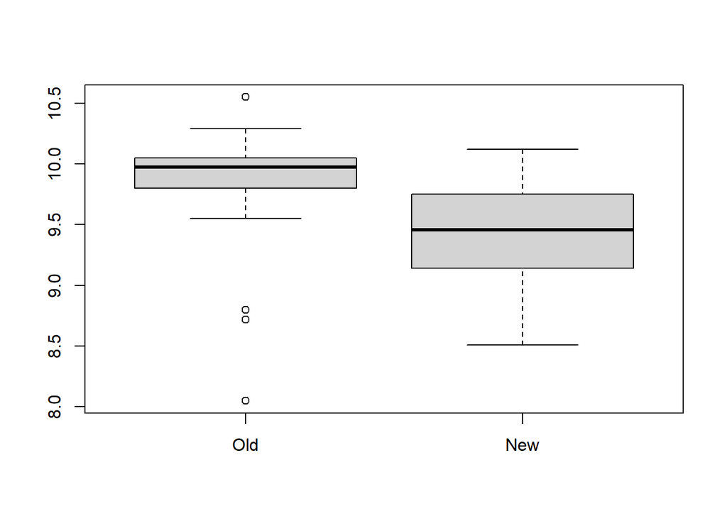

```r
boxplot(old$VOLTAGE, new$VOLTAGE, names = c("Old", "New"))
```

# Question 12

```r
pipe <- read.csv("ROUGHPIPE.csv")
avg = mean(pipe$R)
stddev = sd(pipe$R)
c(avg - (2*stddev), avg + (2*stddev))
```

```
## [1] 0.8331772 2.9288228
```

This is the range of two standard deviations away from the mean in each direction, which according to the empirical rule will contain approximately 95% of the data since the shape of the data is normal.

# Question 13

## (a)

```r
ants = read.csv("GOBIANTS.csv")
head(ants)
```

```
##   Site      Region Rain Temp PlantCov AntSpecies Diversity
## 1    1  Dry Steppe  196  5.7       40          3      0.89
## 2    2  Dry Steppe  196  5.7       52          3      0.83
## 3    3  Dry Steppe  179  7.0       40         52      1.31
## 4    4  Dry Steppe  197  8.0       43          7      1.48
## 5    5  Dry Steppe  149  8.5       27          5      0.97
## 6    6 Gobi Desert  112 10.7       30         49      0.46
```

```r
mean(ants$AntSpecies)
```

```
## [1] 12.81818
```

```r
median(ants$AntSpecies)
```

```
## [1] 5
```

```r
getmode(ants$AntSpecies)
```

```
## [1] 5
```

The mean is the average number of species found. The median is the middle number of species found. The mode is the most common number of species found.

## (b)

I would use the median as the mean is much higher than the median meaning the mean is probably skewed. The mode is just the most common number which could be the largest number appearing twice and hundreds of smaller numbers only appearing once. The median is always in the middle of the data, and in this case seems to be the best measure for this.

## (c)

```r
step = ants[ants$Site < 6,]
mean(step$PlantCov)
```

```
## [1] 40.4
```

```r
median(step$PlantCov)
```

```
## [1] 40
```

```r
getmode(step$PlantCov)
```

```
## [1] 40
```

## (d)

```r
des = ants[ants$Site >= 6,]
mean(des$PlantCov)
```

```
## [1] 28
```

```r
median(des$PlantCov)
```

```
## [1] 26
```

```r
getmode(des$PlantCov)
```

```
## [1] 30
```

## (e)

Yes it appears to be different between the two regions, as the Dry Steppe Sites are around 40 and the Gobi Desert sites are lower down around 28.

# Question 14

## (a)

```r
gal <- read.csv("GALAXY2.csv")
head(gal)
```

```
##   VELOCITY
## 1    22922
## 2    20210
## 3    21911
## 4    19225
## 5    18792
## 6    21993
```

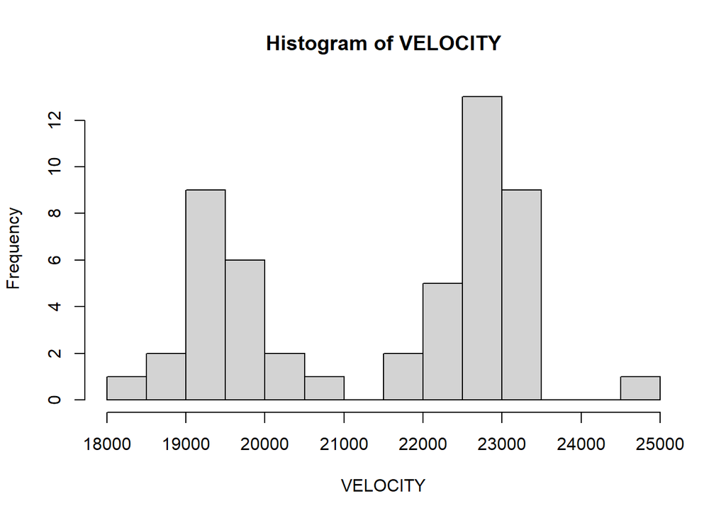

```r
with(gal, hist(VELOCITY, breaks = 10))
```

## (b)

Yes, there is evidence to support the double cluster theory since there are two separate peaks within the graph.

## (c)

```r
A = gal$V[gal$V <= 21000];
B = gal$V[gal$V > 21000];
```

Galaxy A

```r
mean(A)
```

```
## [1] 19462.24
```

```r
sd(A)
```

```
## [1] 532.2868
```

Galaxy B

```r
mean(B)
```

```
## [1] 22838.47
```

```r
sd(B)
```

```
## [1] 560.9767
```

## (d)

If a galaxy velocity of 20,000 km/s is observed it would likely belong to cluster A, since that value is much closer to galaxy A’s mean of 19462.24 than to galaxy B’s mean of 22838.47.

# Question 15

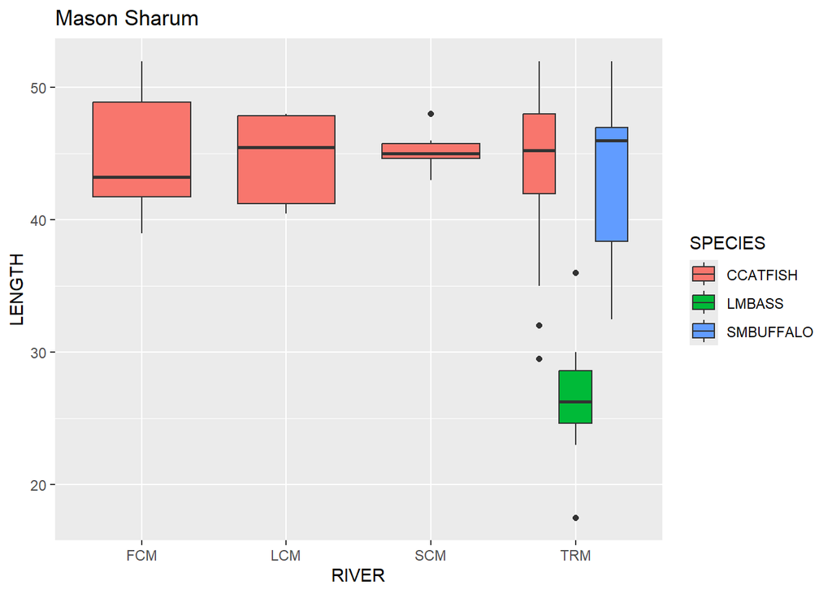

```r
library(ggplot2)
ggplot(ddt, aes(x = RIVER, y = LENGTH)) + geom_boxplot(aes(fill = SPECIES)) + ggtitle("Mason Sharum")
```